# Energy Balance Closure 2019-11-01 Data

```r
library(tidyverse)
source("calc_footprint_FFP.R")
library(ggplot2)
library(modelr)
options(na.action = na.warn)
```

# Lists

```r
rm(list=ls())
```

# Defining the data I/O directory

**"C:-exploring\02_Concord\01_Proccessed_Data\2019-09-25_All_data_To_Date_20190925_Concord_alltodate.csv**

```r
path1<-"C:\\Users\\Tommy\\flux\\Data-exploring\\02_Concord\\"
path.in1<-paste(path1,"01_Proccessed_Data",sep="")
path.out1<-paste(path1,"03_combined_data",sep="")
ver<-"2019-11-01_one_wk_prior"
file.name1<-paste("eddypro_Concord20191101_1wk_prior_full_output_2019-11-04T175830_exp",sep="")
```

# read in eddypro full output file, parse variable names

```r
data20191101<-read.csv(paste(path.in1,"\\",ver,"\\",file.name1,".csv",sep=""),
                  header=F,
                  skip=3,
                  na.strings=c(-9999),
                  stringsAsFactors = F)
colnames(data20191101)<-colnames(
  read.csv(paste(path.in1,"\\",ver,"\\",file.name1,".csv",sep=""),
           header=T,
           skip=1))

data20191101
```

| filename | date | time | DOY | daytime | file_records | used_records | Tau | qc_Tau | H | qc_H | LE | qc_LE | co2_flux | qc_co2_flux | h2o_flux | qc_h2o_flux | H_strg | LE_strg | co2_strg | h2o_strg | co2_v.adv | h2o_v.adv | co2_molar_density | co2_mole_fraction | co2_mixing_ratio | co2_time_lag | co2_def_timelag | h2o_molar_density | h2o_mole_fraction | … |
| --- | --- | --- | --- | --- | --- | --- | --- | --- | --- | --- | --- | --- | --- | --- | --- | --- | --- | --- | --- | --- | --- | --- | --- | --- | --- | --- | --- | --- | --- | --- |
| not_enough_data | 10/23/2019 | 11:30 | 296.4790 | NA | NA | NA | NA | NA | NA | NA | NA | NA | NA | NA | NA | NA | NA | NA | NA | NA | NA | NA | NA | NA | NA | NA | NA | NA | NA | … |
| not_enough_data | 10/23/2019 | 12:00 | 296.4990 | NA | NA | NA | NA | NA | NA | NA | NA | NA | NA | NA | NA | NA | NA | NA | NA | NA | NA | NA | NA | NA | NA | NA | NA | NA | NA | … |
| not_enough_data | 10/23/2019 | 12:30 | 296.5200 | NA | NA | NA | NA | NA | NA | NA | NA | NA | NA | NA | NA | NA | NA | NA | NA | NA | NA | NA | NA | NA | NA | NA | NA | NA | NA | … |
| not_enough_data | 10/23/2019 | 13:00 | 296.5410 | NA | NA | NA | NA | NA | NA | NA | NA | NA | NA | NA | NA | NA | NA | NA | NA | NA | NA | NA | NA | NA | NA | NA | NA | NA | NA | … |
| not_enough_data | 10/23/2019 | 13:30 | 296.5620 | NA | NA | NA | NA | NA | NA | NA | NA | NA | NA | NA | NA | NA | NA | NA | NA | NA | NA | NA | NA | NA | NA | NA | NA | NA | NA | … |
| not_enough_data | 10/23/2019 | 14:00 | 296.5830 | NA | NA | NA | NA | NA | NA | NA | NA | NA | NA | NA | NA | NA | NA | NA | NA | NA | NA | NA | NA | NA | NA | NA | NA | NA | NA | … |
| not_enough_data | 10/23/2019 | 14:30 | 296.6040 | NA | NA | NA | NA | NA | NA | NA | NA | NA | NA | NA | NA | NA | NA | NA | NA | NA | NA | NA | NA | NA | NA | NA | NA | NA | NA | … |
| not_enough_data | 10/23/2019 | 15:00 | 296.6240 | NA | NA | NA | NA | NA | NA | NA | NA | NA | NA | NA | NA | NA | NA | NA | NA | NA | NA | NA | NA | NA | NA | NA | NA | NA | NA | … |
| not_enough_data | 10/23/2019 | 15:30 | 296.6450 | NA | NA | NA | NA | NA | NA | NA | NA | NA | NA | NA | NA | NA | NA | NA | NA | NA | NA | NA | NA | NA | NA | NA | NA | NA | NA | … |
| not_enough_data | 10/23/2019 | 16:00 | 296.6660 | NA | NA | NA | NA | NA | NA | NA | NA | NA | NA | NA | NA | NA | NA | NA | NA | NA | NA | NA | NA | NA | NA | NA | NA | NA | NA | … |

[output cut: 430 more lines]

# Parsing the time stamp converting it into a POSIXlt vector

**interpreting date and time into new timestamp column**

**Then taking that time stamp column and turning each time into a unique number (time.id) so I can join based on that. As it can be really tricky to join/merge based on time stamps alone**

**Or I could make sure both time stamps are characters and match them that way**

**Finally ploting time.id to make sure my times translate linearily**

```r
data20191101$TIMESTAMP<-strptime(paste(data20191101$date,data20191101$time,sep=" "),
                            format="%m/%d/%Y %H:%M", tz = "GMT")

data20191101$time.id <-data20191101$TIMESTAMP$year+1900+(data20191101$TIMESTAMP$yday)/366+(data20191101$TIMESTAMP$hour)/366/24+ (data20191101$TIMESTAMP$min)/366/24/60

data20191101$time.id[1:50]
```

```
 [1] 2019.807 2019.807 2019.807 2019.807 2019.808 2019.808 2019.808 2019.808 2019.808
[10] 2019.808 2019.808 2019.808 2019.808 2019.808 2019.808 2019.808 2019.808 2019.808
[19] 2019.808 2019.808 2019.808 2019.809 2019.809 2019.809 2019.809 2019.809 2019.809
[28] 2019.809 2019.809 2019.809 2019.809 2019.809 2019.809 2019.809 2019.809 2019.809
[37] 2019.809 2019.809 2019.809 2019.810 2019.810 2019.810 2019.810 2019.810 2019.810
[46] 2019.810 2019.810 2019.810 2019.810 2019.810
```

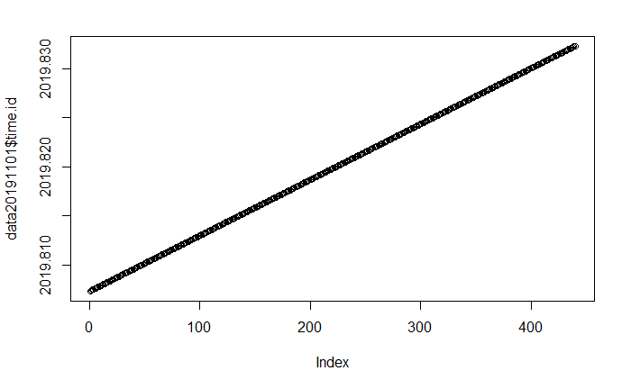

```r
plot(data20191101$time.id)
```

```r
which(duplicated(data20191101$time.id))
```

```
integer(0)
```

# Defining the data I/O directory for met_data

**"C:-exploring\02_Concord\01_Proccessed_Data_data6Series_Concord_Met_20191101.csv"**

```r
path<-"C:\\Users\\Tommy\\flux\\Data-exploring\\02_Concord\\"
path.in<-paste(path,"01_Proccessed_Data",sep="")
path.out3<-paste(path,"03_combined_data",sep="")
ver<-"met_data"
file.name<-paste("CR6Series_Concord_Met_20191101",sep="")
```

#read in Met_Data file, parse variable names and define N/As#

```r
met_data20191101<-read.csv(paste(path.in,"\\",ver,"\\",file.name,".csv",sep=""),
                  header=F,
                  skip=4,
                  na.strings=c("NAN"),
                  stringsAsFactors = F)
colnames(met_data20191101)<-colnames(
  read.csv(paste(path.in,"\\",ver,"\\",file.name,".csv",sep=""),
           header=T,
           skip= 1))

met_data20191101
```

| TIMESTAMP | RECORD | BattV_Avg | PTemp_C_Avg | AM25T_ref_Avg | TC_Avg.1. | TC_Avg.2. | TC_Avg.3. | TC_Avg.4. | TC_Avg.5. | TC_Avg.6. | TC_Avg.7. | TC_Avg.8. | TC_Avg.9. | TC_Avg.10. | TC_Avg.11. | TC_Avg.12. | TC_Avg.13. | TC_Avg.14. | TC_Avg.15. | TC_Avg.16. | TC_Avg.17. | TC_Avg.18. | TC_Avg.19. | TC_Avg.20. | TC_Avg.21. | TC_Avg.22. | TC_Avg.23. | TC_Avg.24. | TC_Avg.25. | … |
| --- | --- | --- | --- | --- | --- | --- | --- | --- | --- | --- | --- | --- | --- | --- | --- | --- | --- | --- | --- | --- | --- | --- | --- | --- | --- | --- | --- | --- | --- | --- |
| 2019-10-24 10:30:00 | 3406 | 12.84 | 27.270 | 29.240 | NA | NA | NA | NA | NA | NA | NA | NA | NA | NA | NA | NA | NA | NA | NA | NA | NA | NA | NA | NA | NA | NA | NA | NA | NA | … |
| 2019-10-24 11:00:00 | 3407 | 12.84 | 28.030 | 35.000 | NA | NA | NA | NA | NA | NA | NA | NA | NA | NA | NA | NA | NA | NA | NA | NA | NA | NA | NA | NA | NA | NA | NA | NA | NA | … |
| 2019-10-24 11:30:00 | 3408 | 12.86 | 28.780 | 31.440 | NA | NA | NA | NA | NA | NA | NA | NA | NA | NA | NA | NA | NA | NA | NA | NA | NA | NA | NA | NA | NA | NA | NA | NA | NA | … |
| 2019-10-24 12:00:00 | 3409 | 12.86 | 29.790 | 29.930 | NA | NA | NA | NA | NA | NA | NA | NA | NA | NA | NA | NA | NA | NA | NA | NA | NA | NA | NA | NA | NA | NA | NA | NA | NA | … |
| 2019-10-24 12:30:00 | 3410 | 12.86 | 30.770 | 29.820 | NA | NA | NA | NA | NA | NA | NA | NA | NA | NA | NA | NA | NA | NA | NA | NA | NA | NA | NA | NA | NA | NA | NA | NA | NA | … |
| 2019-10-24 13:00:00 | 3411 | 12.86 | 31.440 | 30.240 | NA | NA | NA | NA | NA | NA | NA | NA | NA | NA | NA | NA | NA | NA | NA | NA | NA | NA | NA | NA | NA | NA | NA | NA | NA | … |
| 2019-10-24 13:30:00 | 3412 | 12.86 | 31.890 | 30.720 | NA | NA | NA | NA | NA | NA | NA | NA | NA | NA | NA | NA | NA | NA | NA | NA | NA | NA | NA | NA | NA | NA | NA | NA | NA | … |
| 2019-10-24 14:00:00 | 3413 | 12.86 | 31.880 | 30.830 | NA | NA | NA | NA | NA | NA | NA | NA | NA | NA | NA | NA | NA | NA | NA | NA | NA | NA | NA | NA | NA | NA | NA | NA | NA | … |
| 2019-10-24 14:30:00 | 3414 | 12.86 | 32.040 | 31.040 | NA | NA | NA | NA | NA | NA | NA | NA | NA | NA | NA | NA | NA | NA | NA | NA | NA | NA | NA | NA | NA | NA | NA | NA | NA | … |
| 2019-10-24 15:00:00 | 3415 | 12.86 | 32.100 | 31.240 | NA | NA | NA | NA | NA | NA | NA | NA | NA | NA | NA | NA | NA | NA | NA | NA | NA | NA | NA | NA | NA | NA | NA | NA | NA | … |

[output cut: 384 more lines]

```r
NA
```

#Taking the met_data and turning the time stamp into posixt format#

```r
met_data20191101$TIMESTAMP<-strptime(met_data20191101$TIMESTAMP,
                            format="%Y-%m-%d %H:%M:%S", tz = "GMT")

met_data20191101$TIMESTAMP[1:50]
```

```
 [1] "2019-10-24 10:30:00 GMT" "2019-10-24 11:00:00 GMT" "2019-10-24 11:30:00 GMT"
 [4] "2019-10-24 12:00:00 GMT" "2019-10-24 12:30:00 GMT" "2019-10-24 13:00:00 GMT"
 [7] "2019-10-24 13:30:00 GMT" "2019-10-24 14:00:00 GMT" "2019-10-24 14:30:00 GMT"
[10] "2019-10-24 15:00:00 GMT" "2019-10-24 15:30:00 GMT" "2019-10-24 16:00:00 GMT"
[13] "2019-10-24 16:30:00 GMT" "2019-10-24 17:00:00 GMT" "2019-10-24 17:30:00 GMT"
[16] "2019-10-24 18:00:00 GMT" "2019-10-24 18:30:00 GMT" "2019-10-24 19:00:00 GMT"
[19] "2019-10-24 19:30:00 GMT" "2019-10-24 20:00:00 GMT" "2019-10-24 20:30:00 GMT"
[22] "2019-10-24 21:00:00 GMT" "2019-10-24 21:30:00 GMT" "2019-10-24 22:00:00 GMT"
[25] "2019-10-24 22:30:00 GMT" "2019-10-24 23:00:00 GMT" "2019-10-24 23:30:00 GMT"
[28] "2019-10-25 00:00:00 GMT" "2019-10-25 00:30:00 GMT" "2019-10-25 01:00:00 GMT"
[31] "2019-10-25 01:30:00 GMT" "2019-10-25 02:00:00 GMT" "2019-10-25 02:30:00 GMT"
[34] "2019-10-25 03:00:00 GMT" "2019-10-25 03:30:00 GMT" "2019-10-25 04:00:00 GMT"
[37] "2019-10-25 04:30:00 GMT" "2019-10-25 05:00:00 GMT" "2019-10-25 05:30:00 GMT"
[40] "2019-10-25 06:00:00 GMT" "2019-10-25 06:30:00 GMT" "2019-10-25 07:00:00 GMT"
[43] "2019-10-25 07:30:00 GMT" "2019-10-25 08:00:00 GMT" "2019-10-25 08:30:00 GMT"
[46] "2019-10-25 09:00:00 GMT" "2019-10-25 09:30:00 GMT" "2019-10-25 10:00:00 GMT"
[49] "2019-10-25 10:30:00 GMT" "2019-10-25 11:00:00 GMT"
```

#Making sure timestamp columns line up#

```r
met_data20191101$TIMESTAMP[1:10]
```

```
 [1] "2019-10-24 10:30:00 GMT" "2019-10-24 11:00:00 GMT" "2019-10-24 11:30:00 GMT"
 [4] "2019-10-24 12:00:00 GMT" "2019-10-24 12:30:00 GMT" "2019-10-24 13:00:00 GMT"
 [7] "2019-10-24 13:30:00 GMT" "2019-10-24 14:00:00 GMT" "2019-10-24 14:30:00 GMT"
[10] "2019-10-24 15:00:00 GMT"
```

```r
data20191101$TIMESTAMP[1:10]
```

```
 [1] "2019-10-23 11:30:00 GMT" "2019-10-23 12:00:00 GMT" "2019-10-23 12:30:00 GMT"
 [4] "2019-10-23 13:00:00 GMT" "2019-10-23 13:30:00 GMT" "2019-10-23 14:00:00 GMT"
 [7] "2019-10-23 14:30:00 GMT" "2019-10-23 15:00:00 GMT" "2019-10-23 15:30:00 GMT"
[10] "2019-10-23 16:00:00 GMT"
```

```r
met_data20191101
```

| TIMESTAMP | RECORD | BattV_Avg | PTemp_C_Avg | AM25T_ref_Avg | TC_Avg.1. | TC_Avg.2. | TC_Avg.3. | TC_Avg.4. | TC_Avg.5. | TC_Avg.6. | TC_Avg.7. | TC_Avg.8. | TC_Avg.9. | TC_Avg.10. | TC_Avg.11. | TC_Avg.12. | TC_Avg.13. | TC_Avg.14. | TC_Avg.15. | TC_Avg.16. | TC_Avg.17. | TC_Avg.18. | TC_Avg.19. | TC_Avg.20. | TC_Avg.21. | TC_Avg.22. | TC_Avg.23. | TC_Avg.24. | TC_Avg.25. | … |
| --- | --- | --- | --- | --- | --- | --- | --- | --- | --- | --- | --- | --- | --- | --- | --- | --- | --- | --- | --- | --- | --- | --- | --- | --- | --- | --- | --- | --- | --- | --- |
|  | 3406 | 12.84 | 27.270 | 29.240 | NA | NA | NA | NA | NA | NA | NA | NA | NA | NA | NA | NA | NA | NA | NA | NA | NA | NA | NA | NA | NA | NA | NA | NA | NA | … |
|  | 3407 | 12.84 | 28.030 | 35.000 | NA | NA | NA | NA | NA | NA | NA | NA | NA | NA | NA | NA | NA | NA | NA | NA | NA | NA | NA | NA | NA | NA | NA | NA | NA | … |
|  | 3408 | 12.86 | 28.780 | 31.440 | NA | NA | NA | NA | NA | NA | NA | NA | NA | NA | NA | NA | NA | NA | NA | NA | NA | NA | NA | NA | NA | NA | NA | NA | NA | … |
|  | 3409 | 12.86 | 29.790 | 29.930 | NA | NA | NA | NA | NA | NA | NA | NA | NA | NA | NA | NA | NA | NA | NA | NA | NA | NA | NA | NA | NA | NA | NA | NA | NA | … |
|  | 3410 | 12.86 | 30.770 | 29.820 | NA | NA | NA | NA | NA | NA | NA | NA | NA | NA | NA | NA | NA | NA | NA | NA | NA | NA | NA | NA | NA | NA | NA | NA | NA | … |
|  | 3411 | 12.86 | 31.440 | 30.240 | NA | NA | NA | NA | NA | NA | NA | NA | NA | NA | NA | NA | NA | NA | NA | NA | NA | NA | NA | NA | NA | NA | NA | NA | NA | … |
|  | 3412 | 12.86 | 31.890 | 30.720 | NA | NA | NA | NA | NA | NA | NA | NA | NA | NA | NA | NA | NA | NA | NA | NA | NA | NA | NA | NA | NA | NA | NA | NA | NA | … |
|  | 3413 | 12.86 | 31.880 | 30.830 | NA | NA | NA | NA | NA | NA | NA | NA | NA | NA | NA | NA | NA | NA | NA | NA | NA | NA | NA | NA | NA | NA | NA | NA | NA | … |
|  | 3414 | 12.86 | 32.040 | 31.040 | NA | NA | NA | NA | NA | NA | NA | NA | NA | NA | NA | NA | NA | NA | NA | NA | NA | NA | NA | NA | NA | NA | NA | NA | NA | … |
|  | 3415 | 12.86 | 32.100 | 31.240 | NA | NA | NA | NA | NA | NA | NA | NA | NA | NA | NA | NA | NA | NA | NA | NA | NA | NA | NA | NA | NA | NA | NA | NA | NA | … |

[output cut: 384 more lines]

#creating a time id for the MET Data so I I can join the MET and Eddy Pro Data#

```r
met_data20191101$time.id <-met_data20191101$TIMESTAMP$year+1900+(met_data20191101$TIMESTAMP$yday)/366+(met_data20191101$TIMESTAMP$hour)/366/24 + (met_data20191101$TIMESTAMP$min)/366/24/60

met_data20191101$time.id[1:50]
```

```
 [1] 2019.810 2019.810 2019.810 2019.810 2019.810 2019.810 2019.810 2019.810 2019.810
[10] 2019.810 2019.811 2019.811 2019.811 2019.811 2019.811 2019.811 2019.811 2019.811
[19] 2019.811 2019.811 2019.811 2019.811 2019.811 2019.811 2019.811 2019.811 2019.811
[28] 2019.811 2019.812 2019.812 2019.812 2019.812 2019.812 2019.812 2019.812 2019.812
[37] 2019.812 2019.812 2019.812 2019.812 2019.812 2019.812 2019.812 2019.812 2019.812
[46] 2019.812 2019.813 2019.813 2019.813 2019.813
```

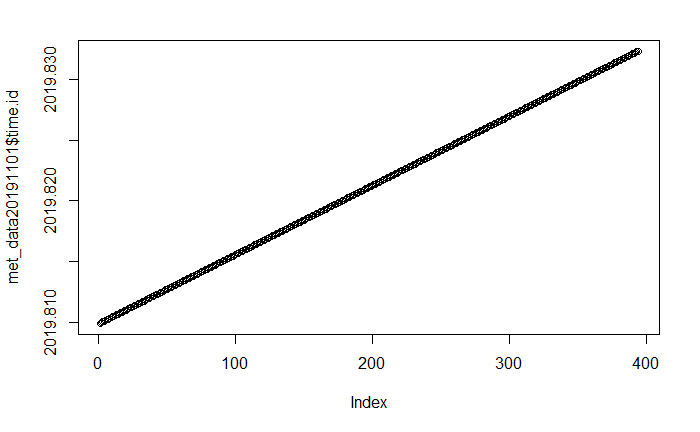

```r
plot(met_data20191101$time.id)
```

```r
which(duplicated(met_data20191101$time.id))
```

```
integer(0)
```

```r
met_data20191101
```

| TIMESTAMP | RECORD | BattV_Avg | PTemp_C_Avg | AM25T_ref_Avg | TC_Avg.1. | TC_Avg.2. | TC_Avg.3. | TC_Avg.4. | TC_Avg.5. | TC_Avg.6. | TC_Avg.7. | TC_Avg.8. | TC_Avg.9. | TC_Avg.10. | TC_Avg.11. | TC_Avg.12. | TC_Avg.13. | TC_Avg.14. | TC_Avg.15. | TC_Avg.16. | TC_Avg.17. | TC_Avg.18. | TC_Avg.19. | TC_Avg.20. | TC_Avg.21. | TC_Avg.22. | TC_Avg.23. | TC_Avg.24. | TC_Avg.25. | … |
| --- | --- | --- | --- | --- | --- | --- | --- | --- | --- | --- | --- | --- | --- | --- | --- | --- | --- | --- | --- | --- | --- | --- | --- | --- | --- | --- | --- | --- | --- | --- |
|  | 3406 | 12.84 | 27.270 | 29.240 | NA | NA | NA | NA | NA | NA | NA | NA | NA | NA | NA | NA | NA | NA | NA | NA | NA | NA | NA | NA | NA | NA | NA | NA | NA | … |
|  | 3407 | 12.84 | 28.030 | 35.000 | NA | NA | NA | NA | NA | NA | NA | NA | NA | NA | NA | NA | NA | NA | NA | NA | NA | NA | NA | NA | NA | NA | NA | NA | NA | … |
|  | 3408 | 12.86 | 28.780 | 31.440 | NA | NA | NA | NA | NA | NA | NA | NA | NA | NA | NA | NA | NA | NA | NA | NA | NA | NA | NA | NA | NA | NA | NA | NA | NA | … |
|  | 3409 | 12.86 | 29.790 | 29.930 | NA | NA | NA | NA | NA | NA | NA | NA | NA | NA | NA | NA | NA | NA | NA | NA | NA | NA | NA | NA | NA | NA | NA | NA | NA | … |
|  | 3410 | 12.86 | 30.770 | 29.820 | NA | NA | NA | NA | NA | NA | NA | NA | NA | NA | NA | NA | NA | NA | NA | NA | NA | NA | NA | NA | NA | NA | NA | NA | NA | … |
|  | 3411 | 12.86 | 31.440 | 30.240 | NA | NA | NA | NA | NA | NA | NA | NA | NA | NA | NA | NA | NA | NA | NA | NA | NA | NA | NA | NA | NA | NA | NA | NA | NA | … |
|  | 3412 | 12.86 | 31.890 | 30.720 | NA | NA | NA | NA | NA | NA | NA | NA | NA | NA | NA | NA | NA | NA | NA | NA | NA | NA | NA | NA | NA | NA | NA | NA | NA | … |
|  | 3413 | 12.86 | 31.880 | 30.830 | NA | NA | NA | NA | NA | NA | NA | NA | NA | NA | NA | NA | NA | NA | NA | NA | NA | NA | NA | NA | NA | NA | NA | NA | NA | … |
|  | 3414 | 12.86 | 32.040 | 31.040 | NA | NA | NA | NA | NA | NA | NA | NA | NA | NA | NA | NA | NA | NA | NA | NA | NA | NA | NA | NA | NA | NA | NA | NA | NA | … |
|  | 3415 | 12.86 | 32.100 | 31.240 | NA | NA | NA | NA | NA | NA | NA | NA | NA | NA | NA | NA | NA | NA | NA | NA | NA | NA | NA | NA | NA | NA | NA | NA | NA | … |

[output cut: 384 more lines]

#Joining the Met_Data and Eddy Pro Data Sets#

**with merge**

**need to add back timestamp**

```r
colnames(Combo20191101)
```

```
  [1] "time.id"                       "RECORD"
  [3] "BattV_Avg"                     "PTemp_C_Avg"
  [5] "AM25T_ref_Avg"                 "TC_Avg.1."
  [7] "TC_Avg.2."                     "TC_Avg.3."
  [9] "TC_Avg.4."                     "TC_Avg.5."
 [11] "TC_Avg.6."                     "TC_Avg.7."
 [13] "TC_Avg.8."                     "TC_Avg.9."
 [15] "TC_Avg.10."                    "TC_Avg.11."
 [17] "TC_Avg.12."                    "TC_Avg.13."
 [19] "TC_Avg.14."                    "TC_Avg.15."
 [21] "TC_Avg.16."                    "TC_Avg.17."
 [23] "TC_Avg.18."                    "TC_Avg.19."
 [25] "TC_Avg.20."                    "TC_Avg.21."
 [27] "TC_Avg.22."                    "TC_Avg.23."
 [29] "TC_Avg.24."                    "TC_Avg.25."
```

[output cut: 71 more lines]

**with left join**

```r
Combo20191101<- met_data20191101 %>%
  left_join(data20191101, by = time.id)
```

```
Error: Column `TIMESTAMP` is a date/time and must be stored as POSIXct, not POSIXlt.
```

#Basic Summary of Eddy Pro Data

```r
summary(data20191101)
```

# filter ustar based on qc_Tau.

**Filtering out all qc_Tau = 2**

```r
data20191101$u.[!is.na(data20191101$qc_Tau)&data20191101$qc_Tau==2]<-NA
```

#Plotting Co2 flux by timstamp on x-axis.

```r
plot(data20191101$TIMESTAMP ,data20191101$co2_flux)
```

# filtering latent heat, sensible heat and h20flux by quality controls

```r
data20191101$LE.[!is.na(data20191101$qc_LE)&data20191101$qc_LE==2]<-NA

data20191101$qqc_h2o_flux[!is.na(data20191101$qc_h2o_flux)&data20191101$qc_h2o_flux==2]<-NA

data20191101$H[!is.na(data20191101$qc_H)&data20191101$qc_H==2]<-NA
```

# latent heat, sensible heat, h20_flux, and relative humidity by day for whole period

```r
plot(data20191101$TIMESTAMP ,data20191101$LE)
hist(data20191101$LE)

plot(data20191101$TIMESTAMP ,data20191101$h2o_flux)

plot(data20191101$TIMESTAMP ,data20191101$H)

plot(data20191101$TIMESTAMP ,data20191101$RH)
```

#h20 flux and co2 flux

```r
plot(data20191101$TIMESTAMP ,data20191101$co2_flux, ylim = c(-6,6))
points(data20191101$TIMESTAMP ,data20191101$h2o_flux,col="red",pch=2)
```

#latent heat and Sensible heat plotted over eachother

```r
plot(data20191101$TIMESTAMP ,data20191101$LE)
points(data20191101$TIMESTAMP ,data20191101$H,col="red",pch=2)
```

#air temperatue by sensible heat an U* by co2 flux

```r
plot(data20191101$air_temperature-273.15,data20191101$H,xlim=c(10,40),ylim=c(-100,500))



plot(data20191101$u. ,data20191101$co2_flux, ylim = c(0, 10), xlim = c(0,1))
```

#Adding best fit line to air temperature by sensible heat

```r
ggplot(data = data20191101) +
  geom_point(mapping = aes(x = air_temperature-273.15, y = H)) +
  geom_smooth(mapping = aes(x = air_temperature-273.15, y = H))

ggplot(data = data20191101) +
  geom_point(mapping = aes(x = air_temperature-273.15, y = H)) +
    geom_smooth(mapping = aes(x = air_temperature-273.15, y = H, method= 'lm', se = FALSE))
```

#best fit line to U* bt co2 flux

```r
ggplot(data = data20191101) +
  geom_point(mapping = aes(x = u., y = co2_flux)) +
  geom_smooth(mapping = aes(x = u., y = co2_flux))
```

**Energy Balance of non-gapfilled data. Slope of line is energy balance closure. Ideally it should be 1:1 Net radiation - soil heat flux= to Latent heat +sensible heat.**

```r
Combo20191101$E_ng <- NR_Wm2_Avg- SHF_1_Wm2_Avg


Combo20191101$E_lh <- LE +H

scatter.smooth(Combo20191101$E_ng, Combo20191101$E_lh)
lm(Combo20191101$E_lh ~ Combo20191101$E_ng)
summary(lm(Combo20191101$E_lh ~ Combo20191101$E_ng))$r.squared
```

```r
library(openair)
library(tidyverse)

hist(data20191101$wind_dir, xlim = c(0,370), breaks = 36, main = "Wind Direction")
```